# Homework 2 - using ggplot2 + dplyr

You will write up your homework in an Rmarkdown document.

- adhere to a style guide
- comment your code - as much as for yourself as for myself and your reviewers
- remember to follow the homework submission instructions online (nothing by email!)
- for a check-plus, we’re looking for you to push yourself
- e.g., try a new technique, provide a high quality walkthrough, make the plots even better

### Part I - Make these plots!

Here is a chance to test out the skills you worked on in class. A few things to keep in mind as you work your way through making these plots:

- plots are made up of layers
- you will learn through trial and error
- we will continue to use the ggplot2 library
- writing out a description of the components of each plot that you see may help

**1) Plot 1**

- use points and colour to identify continents

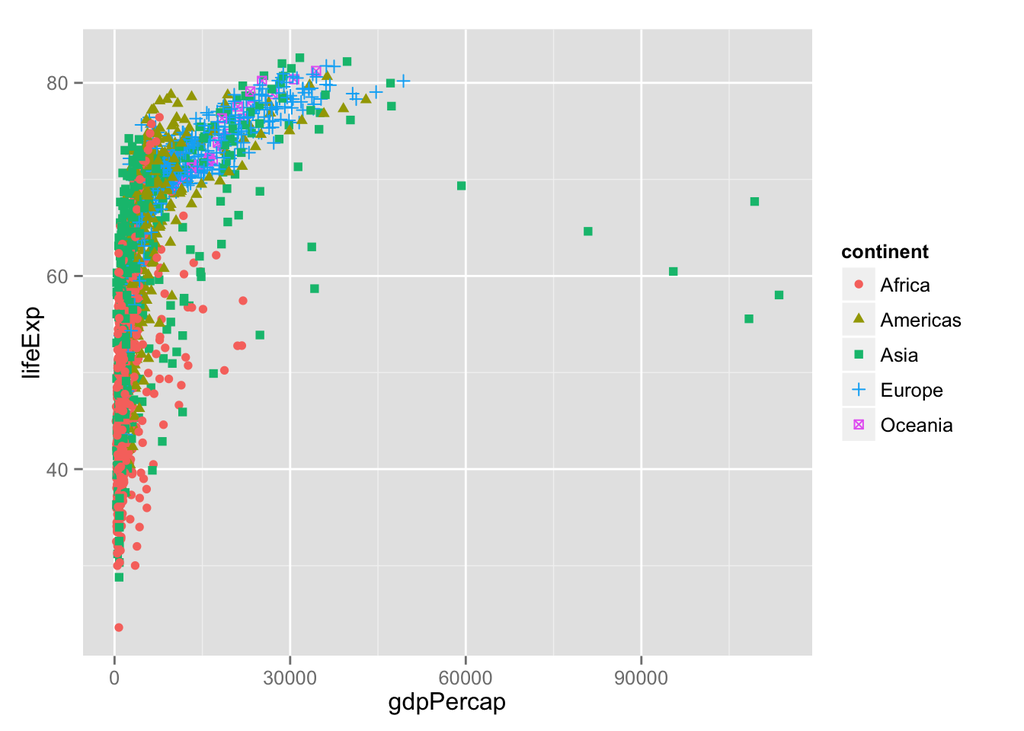

**2) Plot 2**

- the per capita gpd has a very large range, use a transformation to linearise the data

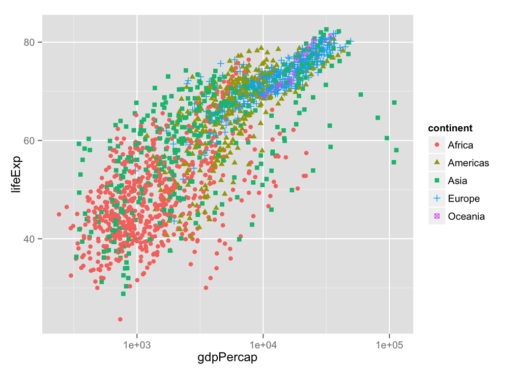

**3) Plot 3**

- include a simple linear fit to the transformed data

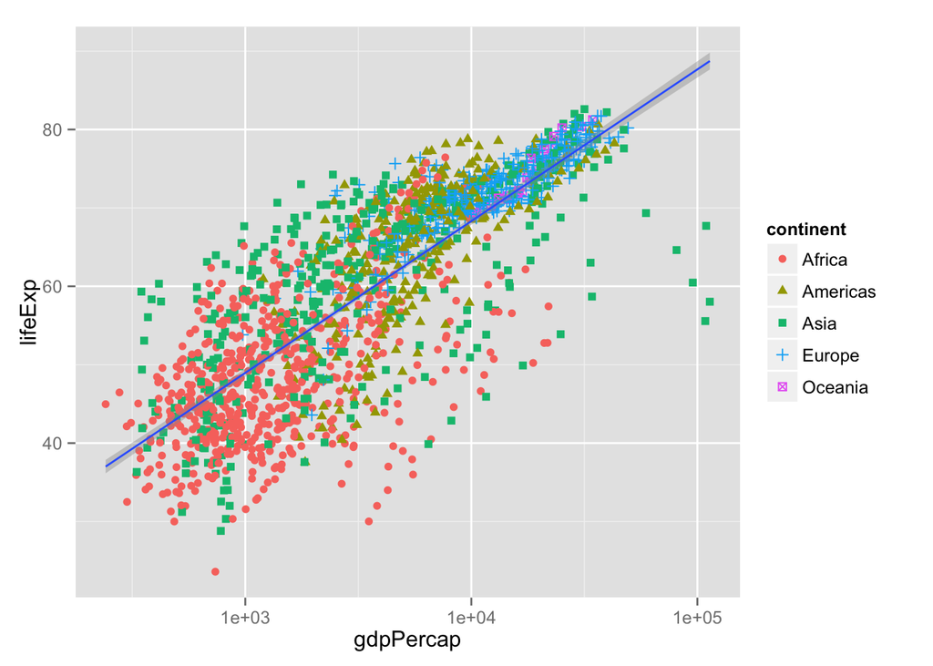

**4) Plot 4**

- plot the density functions of life expectancy for each continent

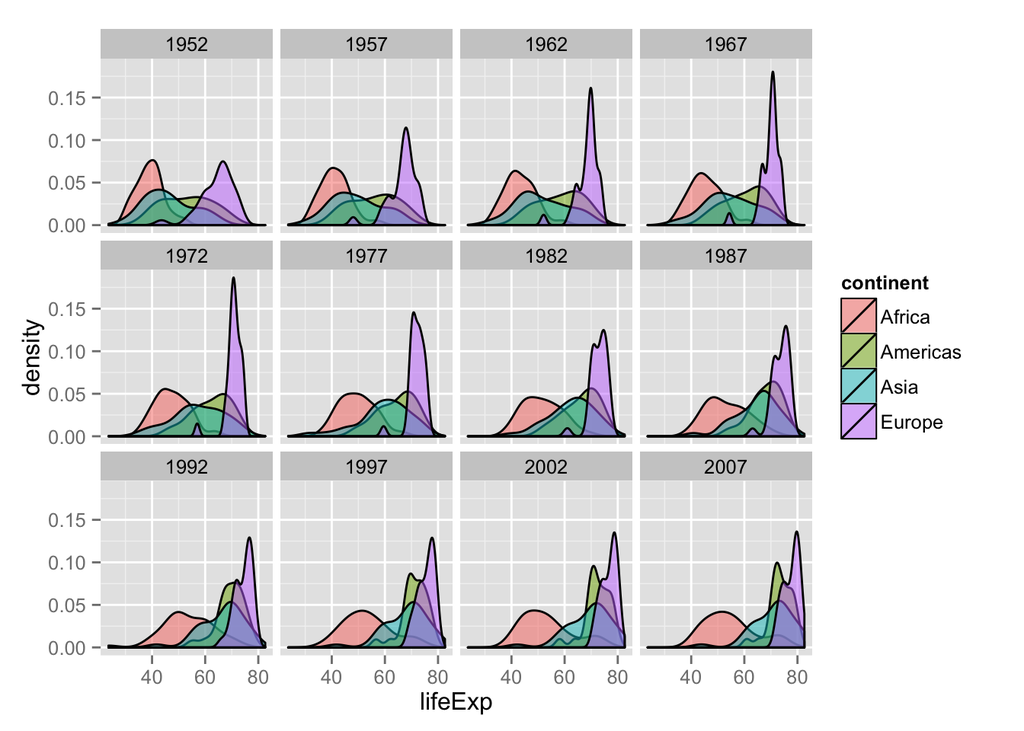

**5) Plot 5**

- for a bonus, fix the bottom continent labels

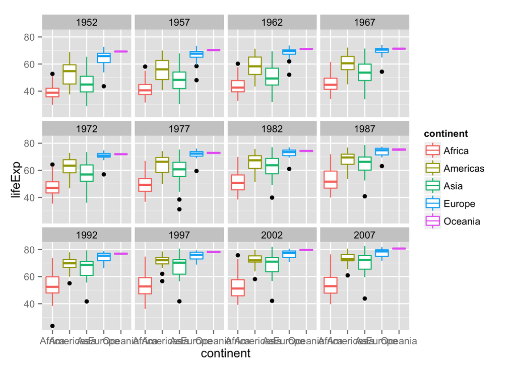

### Part II - Make these plots and then some!

- use dplyr to calculate summary statistics
- the function subset() may be useful (not necessary, just letting you know of a handy function)

**6) Plot 6**

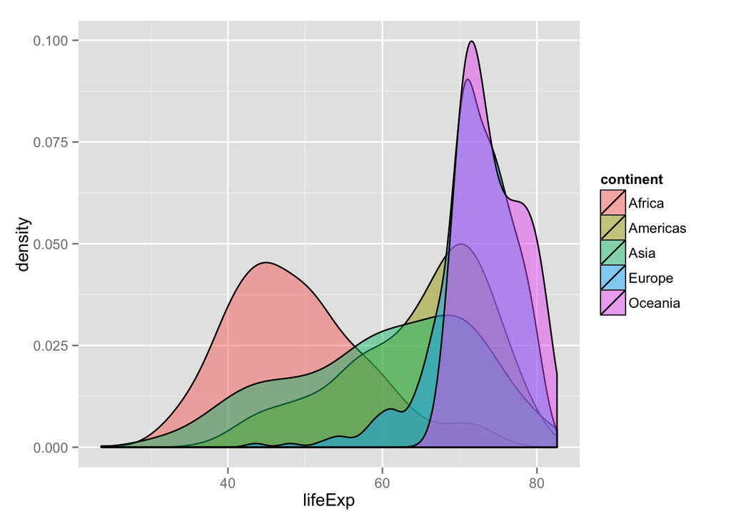

**7) Plot 7**

- plot the mean life expectancy on a density plot for Asia

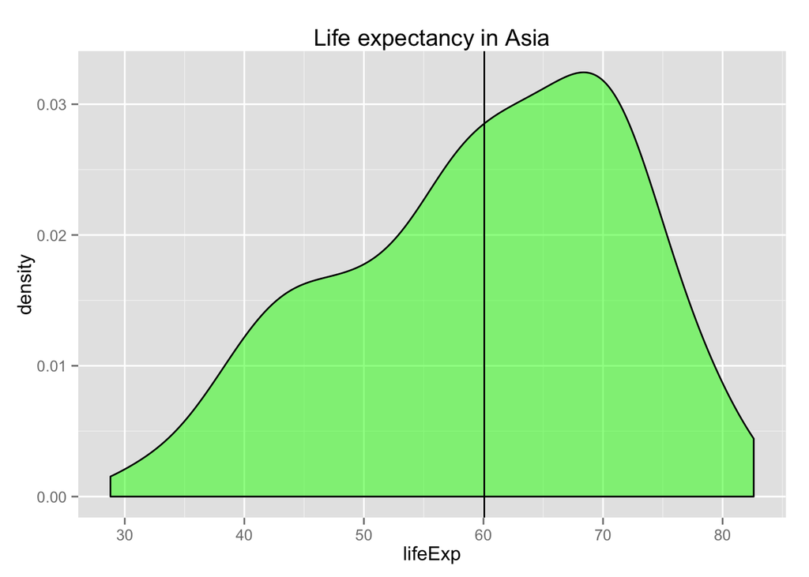

**8) Plot 8**

**a. Create a data.frame of the mean life expectancies for each continent.** You should end up with a data.frame like this

```
## Source: local data frame [5 x 2]
##
##   continent     mean
## 1    Africa 48.86533
## 2  Americas 64.65874
## 3      Asia 60.06490
## 4    Europe 71.90369
## 5   Oceania 74.32621
```

**b. Plot the density plot of life expectancies for each continent and draw a vertical line to mark the mean life expectancy for each continent.**

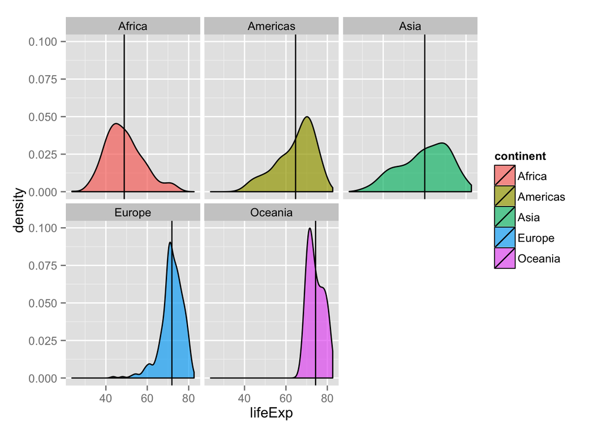

### Part III - Troubleshooting practice

###### *Don’t worry, there is more to read here than actually do. This is mostly a pep talk. The actual homework can be found below*

For a beginner programmer, often one of the hardest things is knowing when you’re doing something *really* wrong, or when you are just making a silly mistake. This is confounded by complicated error messages. But, remember, the computer is *trying* to help you by giving you any error message at all. Embrace error messages and use them. Googling the answer for yourself is likely faster than even asking a friend. This component of this week’s homework is about practicing your troubleshooting and googling skills.

Some pointers (for beyond this assignment):

- check your typing
- check your typing… again
- *actually* read the error message, you may understand more words than you think

When googling:

- start by looking for the most simple looking answer
- personally I choose stackoverflow answers at the top of a google search over any others
- sometimes it just takes time to find the right vocabulary

Asking good questions on forums, or mailing lists is hard. But writing good questions is more likely to get you a better answer. When asking for help online (modified from the stackoverflow ‘how-to-ask’ guidelines:

- demonstrate that you have already looked for a question similar to yours
- write a specific and concise title describing the specific problem (you can practice this on our issues board)
- introduce your problem (verbal description)
- include *reproducible* code (e.g., simplify your problem using a small made up dataset) see [“How to create a Minimal, Complete, and Verifiable example”](http://stackoverflow.com/help/mcve)

#### Find the mistakes!!!!

First, get yourself setup by running the following code. (You may copy and paste this so that you don’t introduce any extra mistakes to fix! But depending on what you have set as your working directory, you may need to adjust the path to where your hw_gapminder.csv file is).

Download this modified gapminder dataset.

```r
library(ggplot2)

hw_gapminder <- read.csv('./hw_gapminder.csv')
```

```r
mean_lifeExp <- mean(hw_gapminder$lifeExpe)

small_set <- hw_gapminder[c(1, 2, 3, 4, 1300:1304), ('country', 'continent', 'year')]

mean_gdp <- mean(hw_gapminder$gdpPercap)

max_country <- hw_gapminder$country[which(hw_gapminder$lifeExp = max(hw_gapminder$lifeExp))]
```

The desired outcomes are:

```r
mean_lifeExp
```

```
## [1] 59.47444
```

```r
small_set
```

```
##                    country continent year
## 1              Afghanistan      Asia 1952
## 2              Afghanistan      Asia 1957
## 3              Afghanistan      Asia 1962
## 4              Afghanistan      Asia 1967
## 1300 Sao Tome and Principe    Africa 1967
## 1301 Sao Tome and Principe    Africa 1972
## 1302 Sao Tome and Principe    Africa 1977
## 1303 Sao Tome and Principe    Africa 1982
## 1304 Sao Tome and Principe    Africa 1987
```

```r
mean_gdp
```

```
## [1] 7210.019
```

```r
max_country
```

```
## [1] "Japan"
```